# Supervised Learning

María Ángeles Magro Garrote

2022

# Introduction

In this project, a data set has been chosen in prder to apply supervised tools to predict our target variable: the Rent of houses. This, will be our study variable both for classification and regression, using it as a factor first, and then as numeric. Furthermore, the relations between the target variable and the rest of variables (predictors) will be explained.

Before continuing, each variable of the dataset will be explained:

- BHK: Number of Bedrooms, Hall, Kitchen.
- Rent: Rent of the Houses/Apartments/Flats.
- Size: Size of the Houses/Apartments/Flats in Square Feet.
- Floor: Houses/Apartments/Flats situated in which Floor and Total Number of Floors (Example: Ground out of 2, 3 out of 5, etc.)
- Area Type: Size of the Houses/Apartments/Flats calculated on either Super Area or Carpet Area or Build Area.
- Area Locality: Locality of the Houses/Apartments/Flats.
- City: City where the Houses/Apartments/Flats are Located.
- Furnishing Status: Furnishing Status of the Houses/Apartments/Flats, either it is Furnished or Semi-Furnished or Unfurnished.
- Tenant Preferred: Type of Tenant Preferred by the Owner or Agent.
- Bathroom: Number of Bathrooms.
- Point of Contact: Whom should you contact for more information regarding the Houses/Apartments/Flats.

Before starting the study, the local enviroment will be cleaned and the necessary libraries will be loaded.

```r
# cleaning environment
rm(list=ls())

# loading libraries
library(VIM)
library(tidyverse)
library(MASS)
library(caret)
library(e1071)
library(GGally)
library(glmnet)
library(pROC)
library(randomForest)
library(caret)
library(rpart)
library(rpart.plot)
library(rattle)
library(naivebayes)
library(leaflet)
```

# Data preprocessing

The dataset will be loaded.

```r
# uploading the csv which contains the data
data = read.csv("House_Rent_Dataset.csv", header = TRUE, sep = ",")
# moving Rent to the first place (target variable)
data = data[,c(3,1,2,4,5,6,7,8,9,10,11,12)]
# getting insights about our data set
head(data)
```

```
##    Rent  Posted.On BHK Size           Floor   Area.Type
## 1 10000 2022-05-18   2 1100 Ground out of 2  Super Area
## 2 20000 2022-05-13   2  800      1 out of 3  Super Area
## 3 17000 2022-05-16   2 1000      1 out of 3  Super Area
## 4 10000 2022-07-04   2  800      1 out of 2  Super Area
## 5  7500 2022-05-09   2  850      1 out of 2 Carpet Area
## 6  7000 2022-04-29   2  600 Ground out of 1  Super Area
##              Area.Locality    City Furnishing.Status Tenant.Preferred Bathroom
## 1                   Bandel Kolkata       Unfurnished Bachelors/Family        2
## 2 Phool Bagan, Kankurgachi Kolkata    Semi-Furnished Bachelors/Family        1
## 3  Salt Lake City Sector 2 Kolkata    Semi-Furnished Bachelors/Family        1
## 4              Dumdum Park Kolkata       Unfurnished Bachelors/Family        1
## 5            South Dum Dum Kolkata       Unfurnished        Bachelors        1
## 6              Thakurpukur Kolkata       Unfurnished Bachelors/Family        2
##   Point.of.Contact
## 1    Contact Owner
## 2    Contact Owner
## 3    Contact Owner
## 4    Contact Owner
## 5    Contact Owner
## 6    Contact Owner
```

# Cleaning

Are there any missing values? The following graph will display that information.

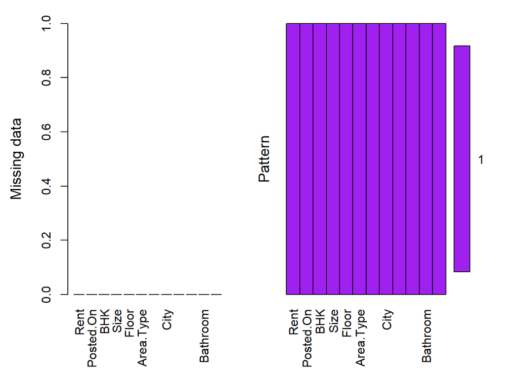

```
##
##  Variables sorted by number of missings:
##           Variable Count
##               Rent     0
##          Posted.On     0
##                BHK     0
##               Size     0
##              Floor     0
##          Area.Type     0
##      Area.Locality     0
##               City     0
##  Furnishing.Status     0
##   Tenant.Preferred     0
##           Bathroom     0
##   Point.of.Contact     0
```

```r
# For missing values, aggr function is used.
aggr(data, numbers = TRUE, sortVars = TRUE, labels = names(data), ylab= c('Missing data','Pattern'), col = c("purple", "red", "orange"))
```

There is no missing values. Then, it will be checked if there is any duplicated data. In case there is, it will be deleted as there is enough data.

```r
if(sum(duplicated(data))!= 0) {
  data = data[!duplicated(data), ]
}
```

For finishing the data cleaning, the outliers of our study variable will be checked.

```r
QI <- quantile(data$Rent, 0.25)
QS <- quantile(data$Rent, 0.75)
IQR = QS-QI

sum(data$Rent < QI - 1.5*IQR | data$Rent > QS + 1.5*IQR)
```

```
## [1] 520
```

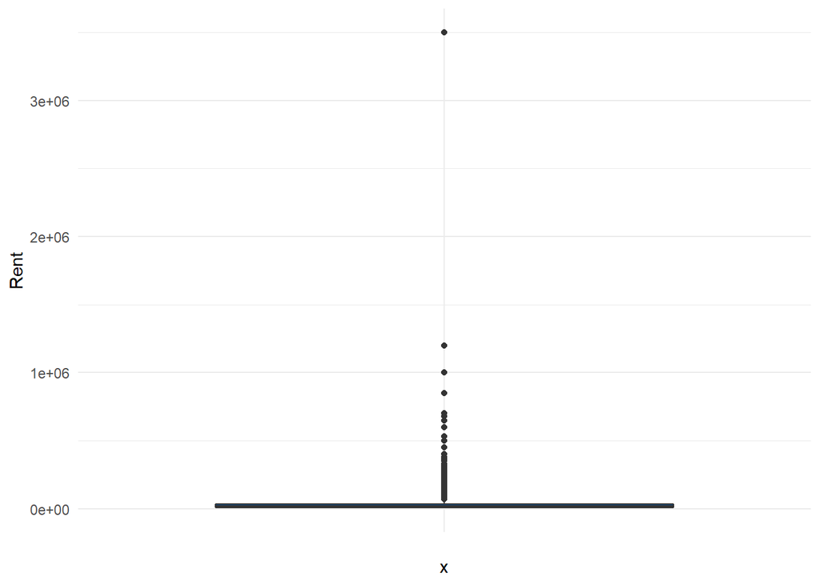

```r
ggplot(data) +
  aes(x = "", y = Rent) +
  geom_boxplot(fill = "#0c4c8a") +
  theme_minimal()
```

We have 520 outliers. As our data set is big, they will be erased.

```r
# saving outliers with $out
outliers <- boxplot(data$Rent, plot=FALSE)$out
# eliminating them from the dataset
data <- data[-which(data$Rent %in% outliers),]
```

# Feature engineering

There are some variables which have many different levels, which will only produce noise in our study, so they will be erased. In this case, they are Floor and Area.Locality variables.

```r
# erasing floor and area locality
data = data[,-c(5, 7)]
```

Furthermore, all the data is from 2022. So from the variable Posted.on it is only interesting saving the month. For that, it will be used the function substr in order to save from the position 6 to the 7 of each row.

```r
for(i in 1:nrow(data)) {
  data[i,2] <- substr(data[i,2], 6, 7)
}
# casting it as numeric
data$Posted.On = as.numeric(data$Posted.On)
# saving this before editing
data.num = data
```

# Visualization

The correlation coefficients with the study variable (Rent) can be shown so an insight is obtained from the relations our variables share. Only our numeric variables are used:

```r
R = cor(data[, c(1,3,4,9)]);R
```

```
##               Rent       BHK      Size  Bathroom
## Rent     1.0000000 0.4012683 0.3936050 0.5065275
## BHK      0.4012683 1.0000000 0.6984532 0.7479183
## Size     0.3936050 0.6984532 1.0000000 0.6806073
## Bathroom 0.5065275 0.7479183 0.6806073 1.0000000
```

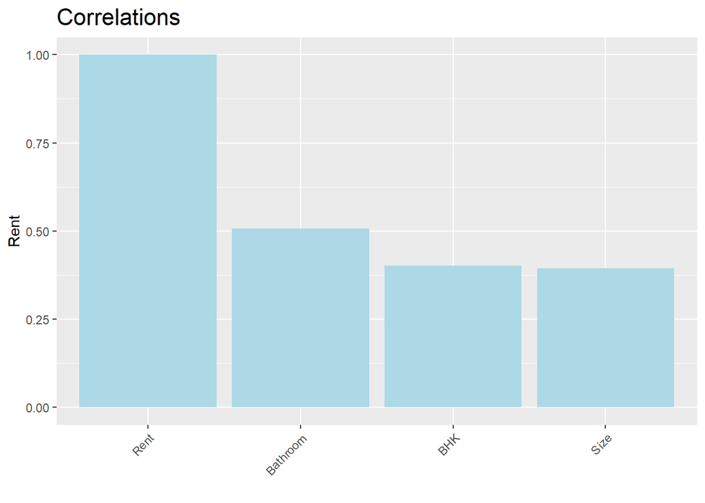

```r
corr_delay <- sort(cor(data[, c(1,3,4,9)])["Rent",], decreasing = T)
corr=data.frame(corr_delay)
ggplot(corr,aes(x = row.names(corr), y = corr_delay)) +
  geom_bar(stat = "identity", fill = "lightblue") +
  scale_x_discrete(limits= row.names(corr)) +
  labs(x = "", y = "Rent", title = "Correlations") +
  theme(plot.title = element_text(hjust = 0, size = rel(1.5)),
        axis.text.x = element_text(angle = 45, hjust = 1))
```

With this, some ideas have been gotten.

- Rent and Size / Area.Type

Let’s compare Rent values with the Size of the houses. They will be colored by the type the house is located in.

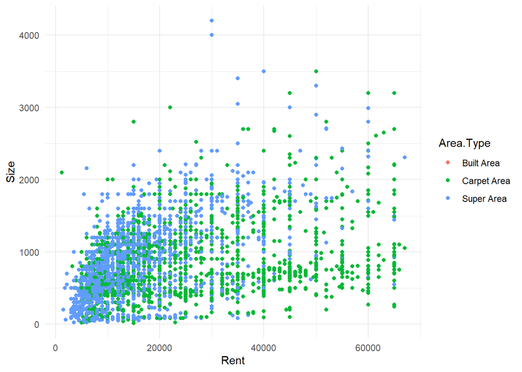

```r
ggplot(data) +
  aes(x = Rent, y = Size, colour = Area.Type) +
  geom_point(shape = "circle", size = 1.5) +
  scale_color_hue(direction = 1) +
  theme_minimal()
```

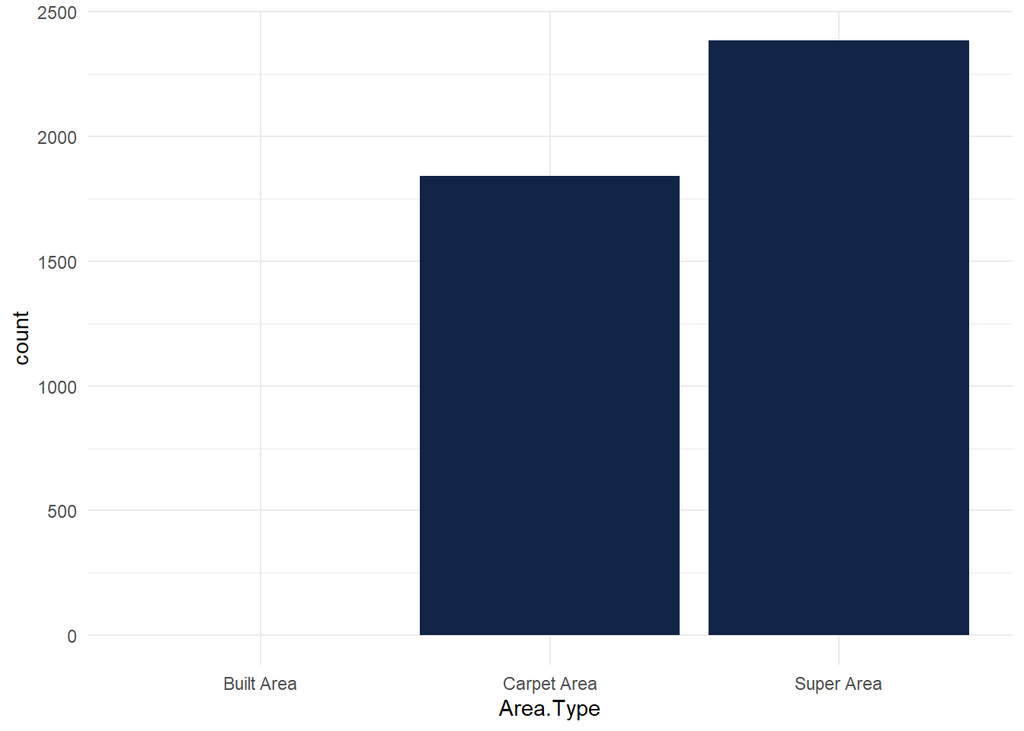

```r
ggplot(data) +
  aes(x = Area.Type) +
  geom_bar(fill = "#112446") +
  theme_minimal()
```

```r
data %>% count(Area.Type, sort = TRUE)
```

```
##     Area.Type    n
## 1  Super Area 2383
## 2 Carpet Area 1841
## 3  Built Area    2
```

No enough information for learning from Built Area.

```r
mean(data$Rent[which(data$Area.Type=="Super Area")])
```

```
## [1] 15522.5
```

```r
mean(data$Rent[which(data$Area.Type=="Carpet Area")])
```

```
## [1] 24167.41
```

```r
mean(data$Rent[which(data$Area.Type=="Built Area")])
```

```
## [1] 10500
```

As stated before, the mean of carpet area houses is higher than the one of super area houses. The mean of houses in built area is far lower than the other levels.

- City

Is city a well balanced variable?

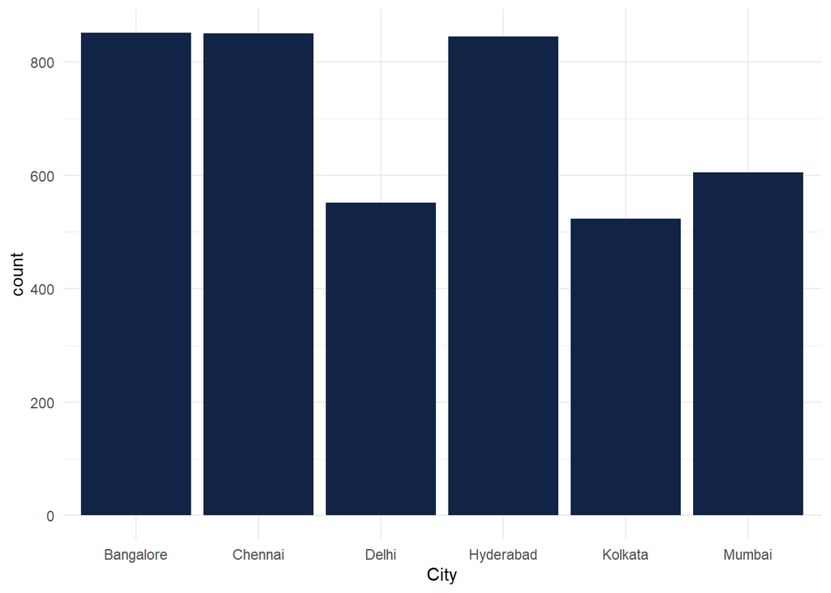

```r
ggplot(data) +
  aes(x = City) +
  geom_bar(fill = "#112446") +
  theme_minimal()
```

As seen, there is values for every city. Is there any city expensive?

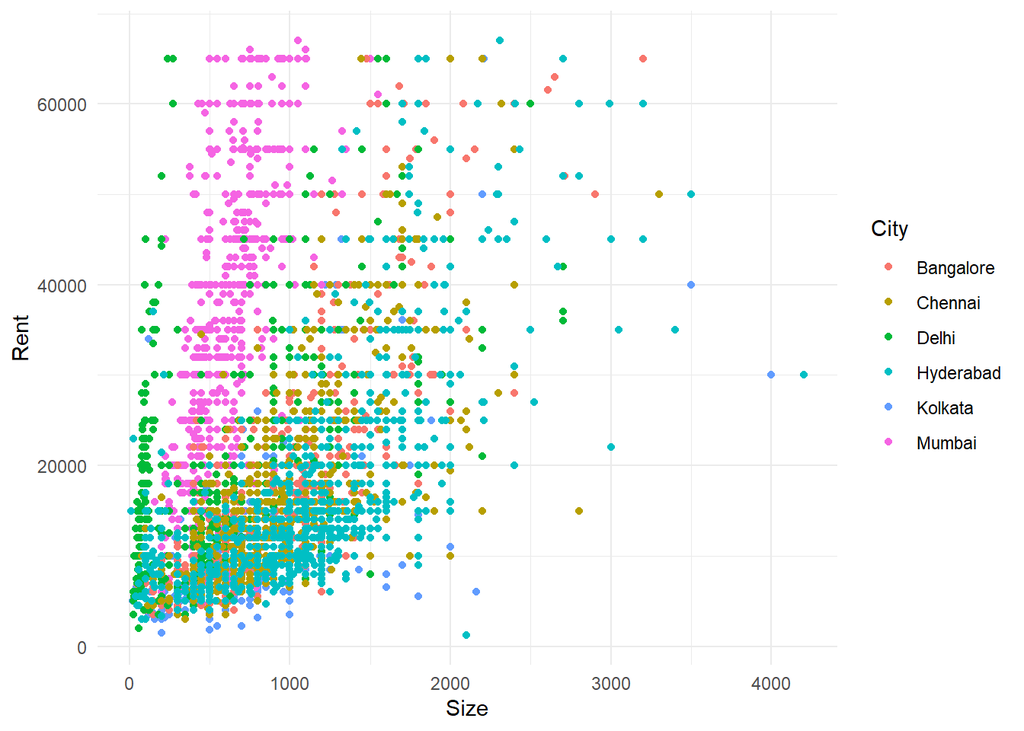

```r
ggplot(data) +
  aes(x = Size, y = Rent, colour = City) +
  geom_point(shape = "circle", size = 1.5) +
  scale_color_hue(direction = 1) +
  theme_minimal()
```

The first most noticeable thing is that houses from Mumbai are grouped all at low values of size but the highest of rent.

Furthermore, Hyderabad houses follow the expected distribution: the higher the size, the higher the price.

A separate analysis can be done:

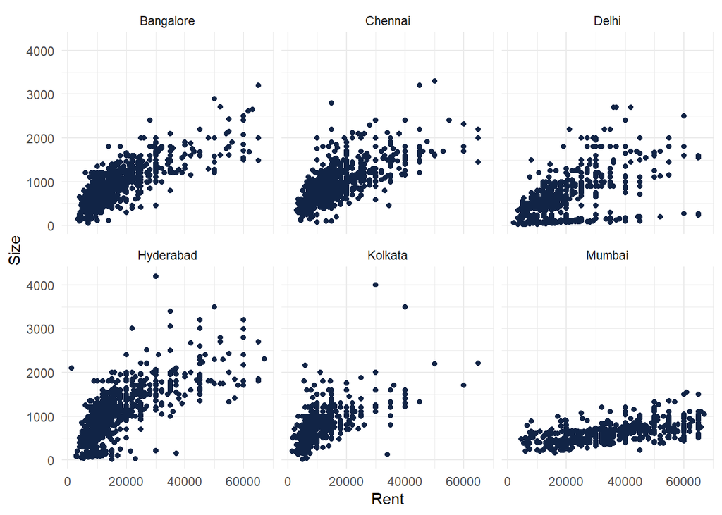

```r
ggplot(data) +
  aes(x = Rent, y = Size) +
  geom_point(shape = "circle", size = 1.5, colour = "#112446") +
  theme_minimal() +
  facet_wrap(vars(City))
```

As observed, Mumbai achieves our before statement. The rest of countries follow an expected distribution.

- Bathroom, BHK, Size

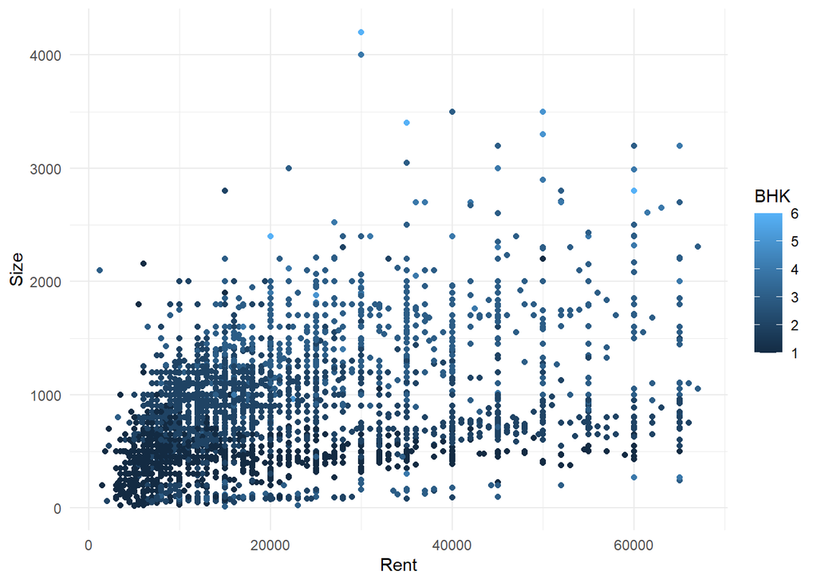

```r
ggplot(data) +
  aes(x = Rent, y = Size, colour = BHK) +
  geom_point(shape = "circle", size = 1.5) +
  scale_color_gradient() +
  theme_minimal()
```

Smaller number of BHK are concentrated in lower values of rent and size, while higher number of BHK goes higher in the graph.

Does the same happen with Bathroom?

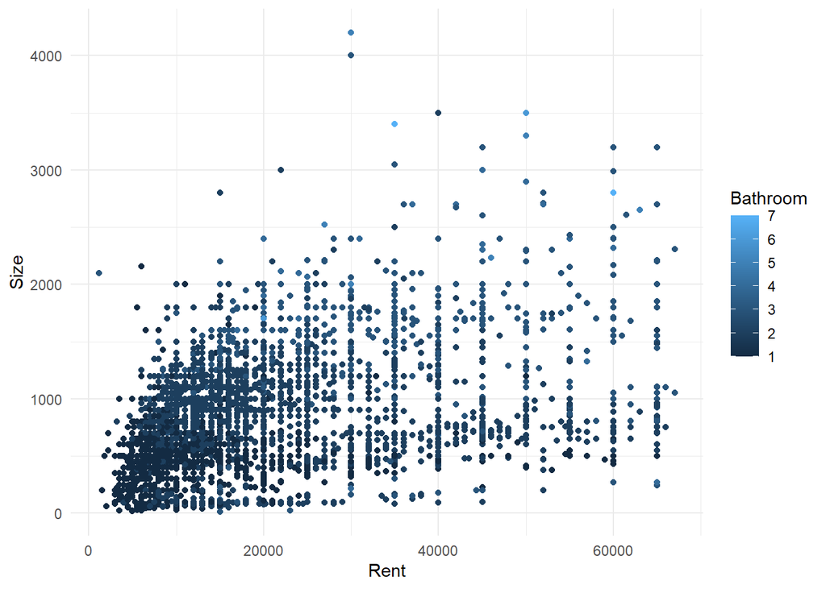

```r
ggplot(data) +
  aes(x = Rent, y = Size, colour = Bathroom) +
  geom_point(shape = "circle", size = 1.5) +
  scale_color_gradient() +
  theme_minimal()
```

Again, a similar graph is obtained. So are BHK and Bathroom correlated? Previously it has been showed that yes which Would make sense because the bigger the house is, the more bathroom it may have and also bedroom, kitchens, etc…

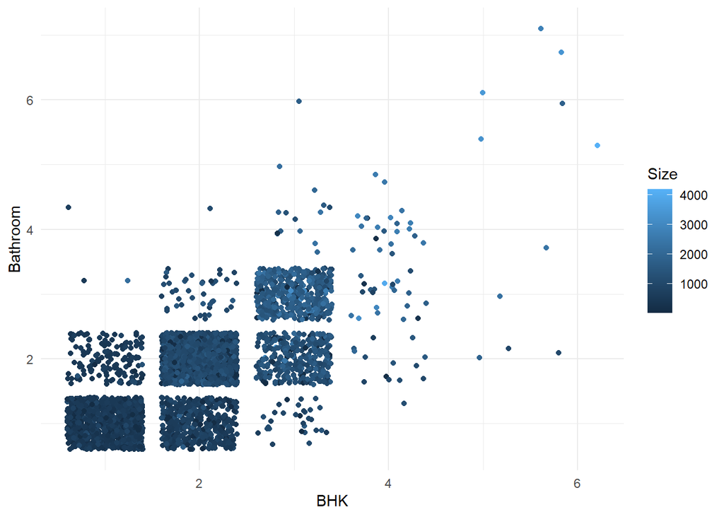

```r
ggplot(data) +
  aes(x = BHK, y = Bathroom, color = Size) +
  geom_jitter(size = 1.5) +
  theme_minimal()
```

Which shows the correlation among both variables.

- Furnishing.Status

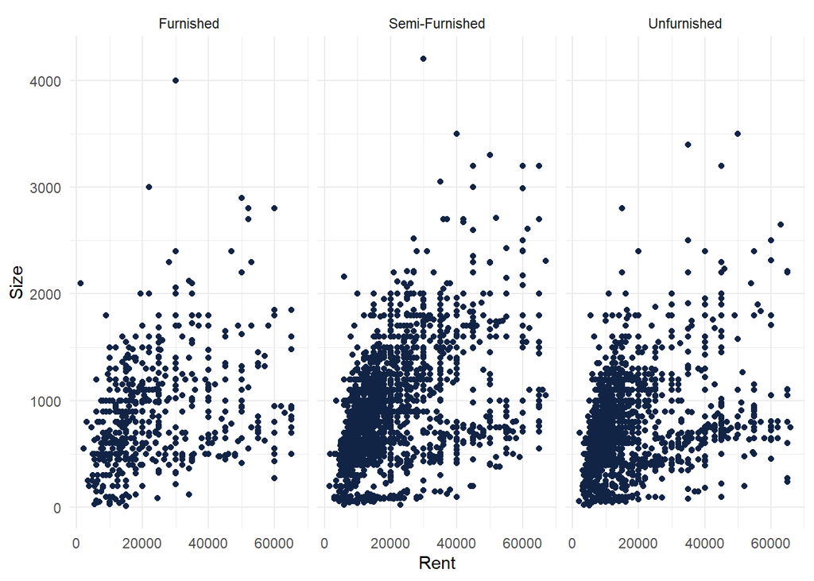

```r
ggplot(data) +
  aes(x = Rent, y = Size) +
  geom_point(shape = "circle", size = 1.5, colour = "#112446") +
  theme_minimal() +
  facet_wrap(vars(Furnishing.Status))
```

The state of the furnishes does seem to affect not the price neither the rent.

```r
mean(data$Rent[which(data$Furnishing.Status=="Unfurnished")])
```

```
## [1] 16338.19
```

```r
mean(data$Rent[which(data$Furnishing.Status=="Semi-Furnished")])
```

```
## [1] 20392.36
```

```r
mean(data$Rent[which(data$Furnishing.Status=="Furnished")])
```

```
## [1] 24827.9
```

We see that the the price of the furniture increase a little by increasing the status. So it may affect, although the relationship with rent is not as stronger.

- CONCLUSION

It has been seen that Rent may be related with the Size mainly but also with the BHK and Bathroom, which are related to Size. Furniture is also a factor to take into account although not as strongly as city, as almost all of them are correlated with a correlated Size and Rent.

# Classification

Before starting different methods, our study variable (Rent) must be classified depending on the price the house has.

We will divide it into “very cheap”, “cheap”, “expensive” and “very expensive” according to the information provided by the quartiles of the summary function.

```r
table(data$Rent)
```

```
##
##  1200  1500  1800  2000  2200  3000  3200  3300  3500  3700  3800  3900  4000
##     1     1     1     1     2     8     2     2    13     1     1     1    15
##  4200  4300  4500  4600  4700  4750  4800  5000  5146  5200  5250  5300  5400
##     1     1    18     1     6     1     1    87     1     4     1     3     1
##  5500  5700  5800  6000  6166  6200  6250  6300  6500  6700  6800  6900  7000
##    36     2     1   113     1     3     1     2    73     1     5     1   130
##  7200  7500  7600  7700  7900  8000  8200  8500  8900  9000  9250  9300  9400
##     2    90     1     1     1   162     5    83     2   131     1     4     1
##  9500  9750  9800  9900 10000 10500 10677 11000 11200 11400 11500 12000 12100
##    49     1     1     1   248    25     1   103     1     1    17   238     1
## 12333 12500 13000 13500 13900 14000 14500 14900 15000 15500 15723 16000 16500
##     1    51   118    23     2   125    17     1   275    10     1   109    20
## 17000 17401 17500 17600 17681 18000 18500 18999 19000 19397 19411 19500 19800
##    74     1    14     1     1   128    13     1    22     1     1     6     1
## 20000 20200 20500 21000 21467 21500 22000 22500 22999 23000 23382 23500 23999
##   175     1     4    37     1     1    91     4     2    35     1     2     2
## 24000 24500 25000 25500 26000 26500 26969 27000 27500 27999 28000 28500 29000
##    43     1   136     2    31     1     1    33     3     1    30     2    10
## 29500 29999 30000 31000 31500 32000 32500 32900 33000 33003 33500 34000 34500
##     1     1   117     7     1    45     1     1    15     1     2    15     1
## 34999 35000 35500 36000 36125 37000 37500 38000 39000 40000 41000 42000 42500
##     3    91     1    20     1    13     2    15     9    82     3    18     1
## 43000 43500 44000 44300 45000 45002 46000 46700 47000 47500 48000 49000 49500
##    10     1     6     1    77     1     7     1     8     1     9     4     1
## 50000 51000 51500 52000 53000 53500 54000 54500 55000 55100 56000 57000 58000
##    49     2     1    15     7     1     3     2    51     1     3     8     4
## 59000 60000 61000 61500 62000 63000 65000 66000 67000
##     1    45     1     1     6     2    43     2     2
```

```r
summary(data$Rent)
```

```
##    Min. 1st Qu.  Median    Mean 3rd Qu.    Max.
##    1200    9500   15000   19286   25000   67000
```

```r
data$Rent = factor(ifelse(data$Rent  <= 9500 , "Very_cheap",
                   ifelse(data$Rent <= 15000, "Cheap",
                   ifelse(data$Rent <= 19286, "Expensive",
                    "Very_expensive"))))
```

Our data set is now divided like:

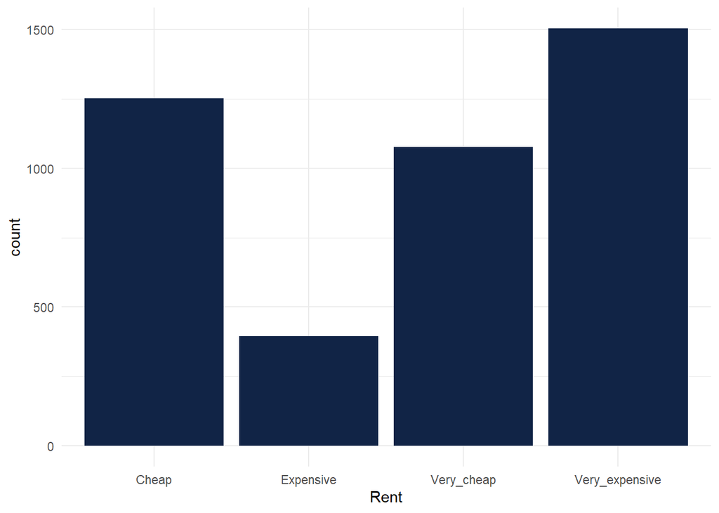

```r
ggplot(data) +
  aes(x = Rent) +
  geom_bar(fill = "#112446") +
  theme_minimal()
```

```r
table(data$Rent, data$City)
```

```
##
##                  Bangalore Chennai Delhi Hyderabad Kolkata Mumbai
##   Cheap                288     322   162       308     136     35
##   Expensive            101     101    60        82      19     32
##   Very_cheap           228     204   115       210     299     21
##   Very_expensive       234     223   215       245      69    517
```

Now, the train and test set will be created. The variable that is going to be predicted (dependent) is Rent.

```r
spl = createDataPartition(data$Rent, p = 0.8, list = FALSE)  # 80% for training

dataTrain = data[spl,]
dataTest = data[-spl,]
```

# LDA

The first method applied of classification will be Linear Discriminant Analysis. In order to build the model, the train data set will be used.

```r
# LDA model
lda.model <- lda(Rent ~ ., data=dataTrain)
lda.model
```

```
## Call:
## lda(Rent ~ ., data = dataTrain)
##
## Prior probabilities of groups:
##          Cheap      Expensive     Very_cheap Very_expensive
##     0.29597871     0.09343584     0.25487877     0.35570668
##
## Group means:
##                Posted.On      BHK      Size Area.TypeCarpet Area
## Cheap           5.649351 1.927073  827.6763            0.3456543
## Expensive       5.724684 2.034810  916.3386            0.4145570
## Very_cheap      5.547564 1.435035  566.2135            0.3190255
## Very_expensive  5.887781 2.337490 1120.5021            0.6084788
##                Area.TypeSuper Area CityChennai CityDelhi CityHyderabad
## Cheap                    0.6543457   0.2667333 0.1328671     0.2417582
## Expensive                0.5854430   0.2468354 0.1582278     0.2088608
## Very_cheap               0.6798144   0.1786543 0.1044084     0.1937355
## Very_expensive           0.3915212   0.1512884 0.1396509     0.1645885
##                CityKolkata CityMumbai Furnishing.StatusSemi-Furnished
## Cheap           0.10589411 0.02597403                       0.4615385
## Expensive       0.03797468 0.07911392                       0.5474684
## Very_cheap      0.27958237 0.01972158                       0.3515081
## Very_expensive  0.04738155 0.34663342                       0.5369909
##                Furnishing.StatusUnfurnished Tenant.PreferredBachelors/Family
## Cheap                             0.4355644                        0.7632368
## Expensive                         0.3037975                        0.7310127
## Very_cheap                        0.5812065                        0.8422274
## Very_expensive                    0.2826268                        0.6384040
##                Tenant.PreferredFamily Bathroom Point.of.ContactContact Builder
## Cheap                      0.07592408 1.730270                     0.000000000
## Expensive                  0.08860759 1.879747                     0.000000000
## Very_cheap                 0.03016241 1.250580                     0.001160093
## Very_expensive             0.13216958 2.240233                     0.000000000
##                Point.of.ContactContact Owner
## Cheap                              0.9100899
## Expensive                          0.8164557
## Very_cheap                         0.9187935
## Very_expensive                     0.4754780
##
## Coefficients of linear discriminants:
##                                           LD1           LD2           LD3
## Posted.On                         0.060361612 -0.0577306556 -0.0787097788
## BHK                               0.584709697 -0.5910306652  0.7547776017
## Size                              0.001108301  0.0004901868 -0.0003426576
## Area.TypeCarpet Area              0.159203203 -4.2642369722  4.0263241850
## Area.TypeSuper Area               0.134847846 -4.0855676568  4.3855043956
## CityChennai                      -0.080082676 -0.2538298771  1.1831267613
## CityDelhi                         0.581320274  0.0206250850  0.3762377184
## CityHyderabad                    -0.335233471  0.0732595218  1.4241894858
## CityKolkata                      -0.673623808  1.9436906350  1.3409985827
## CityMumbai                        2.401233589  1.0642509133  1.3738480657
## Furnishing.StatusSemi-Furnished  -0.354672299  0.1305781823  0.4616500419
## Furnishing.StatusUnfurnished     -0.768550642  0.4302066829  1.5179078832
## Tenant.PreferredBachelors/Family -0.195124270  0.4671860474 -0.0489926603
## Tenant.PreferredFamily           -0.194822475  0.0124615413  0.2280858008
## Bathroom                          0.380188676 -0.1332602307 -0.0063149411
## Point.of.ContactContact Builder  -0.832075937  2.8354871605 -4.2285182564
## Point.of.ContactContact Owner    -0.808058213 -1.2990991781  0.1912518979
##
## Proportion of trace:
##    LD1    LD2    LD3
## 0.9456 0.0519 0.0025
```

It has been obtained the prior probabilities (percentages of data belonging to that type in the training set), the group means (means of each group belonging to that category) and the coefficients of linear discriminants (the combinations used to form the LDA). As there is 4 groups, there are 3 linear classifiers.

Our LDA model can be shown also using ggplot:

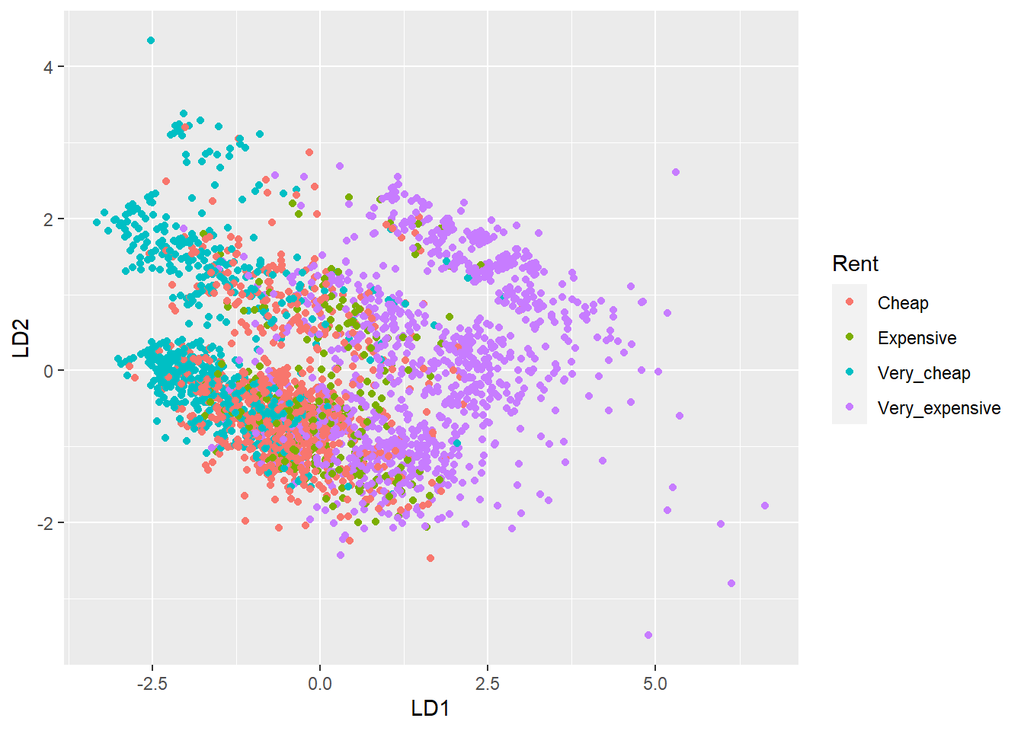

```r
lda.data <- cbind(dataTrain, predict(lda.model)$x)
ggplot(lda.data, aes(LD1, LD2)) +
  geom_point(aes(color = Rent))
```

With this information, it can be predicted an output with our test set. It can be computed the probabilities and the prediction using “posterior” and “class.”

```r
# predictions
probability = predict(lda.model, newdata=dataTest)$posterior
head(probability)
```

```
##        Cheap  Expensive Very_cheap Very_expensive
## 1  0.2458418 0.02927910 0.70366642    0.021212707
## 3  0.2442517 0.03578965 0.70290623    0.017052384
## 9  0.2751645 0.05487957 0.52481800    0.145137908
## 16 0.2978821 0.13282496 0.08567399    0.483618999
## 19 0.2806048 0.05813524 0.53392694    0.127333011
## 20 0.1469362 0.01090096 0.83996509    0.002197793
```

```r
prediction = predict(lda.model, newdata=dataTest)$class
head(prediction)
```

```
## [1] Very_cheap     Very_cheap     Very_cheap     Very_expensive Very_cheap
## [6] Very_cheap
## Levels: Cheap Expensive Very_cheap Very_expensive
```

With this information, predictions can be made according to some data provided in order to determine the most possible output of Rent as seen in probability with the Test set.

Probability will give us the percentages of belonging to all the classifications of each row of the data set.

In prediction, each observation received is the most possible classification, receiving only one per row of the data set in our case.

Finally, the accuracy of our model can be computed with the actual values of the Rent. It will be used the prediction computed before and will be compared with the test set. Notice that both must have the same lengths and levels.

```r
# computing accuracy
confusionMatrix(prediction, dataTest$Rent)
```

```
## Confusion Matrix and Statistics
##
##                 Reference
## Prediction       Cheap Expensive Very_cheap Very_expensive
##   Cheap            176        46         57             62
##   Expensive          0         0          0              0
##   Very_cheap        51         8        150              5
##   Very_expensive    23        25          8            233
##
## Overall Statistics
##
##                Accuracy : 0.6623
##                  95% CI : (0.6293, 0.6942)
##     No Information Rate : 0.3555
##     P-Value [Acc > NIR] : < 2.2e-16
##
##                   Kappa : 0.5134
##
##  Mcnemar's Test P-Value : < 2.2e-16
##
## Statistics by Class:
##
##                      Class: Cheap Class: Expensive Class: Very_cheap
## Sensitivity                0.7040           0.0000            0.6977
## Specificity                0.7222           1.0000            0.8983
## Pos Pred Value             0.5161              NaN            0.7009
## Neg Pred Value             0.8529           0.9064            0.8968
## Prevalence                 0.2962           0.0936            0.2547
## Detection Rate             0.2085           0.0000            0.1777
## Detection Prevalence       0.4040           0.0000            0.2536
## Balanced Accuracy          0.7131           0.5000            0.7980
##                      Class: Very_expensive
## Sensitivity                         0.7767
## Specificity                         0.8971
## Pos Pred Value                      0.8062
## Neg Pred Value                      0.8793
## Prevalence                          0.3555
## Detection Rate                      0.2761
## Detection Prevalence                0.3424
## Balanced Accuracy                   0.8369
```

```r
confusionMatrix(prediction, dataTest$Rent)$overall[1]
```

```
##  Accuracy
## 0.6623223
```

# QDA

Quadratic Discriminant Analysis will be now performed. In order not to get an error of rank deficiency, some variables must be eliminated because they are some how correlated and will only provide us redundancy.

```r
# Area.type and Point.of.contact are subtracted (provide us rank deficiency)
data_aux=data[,-c(5,10)]
dataTrain_aux = data_aux[spl,]
dataTest_aux = data_aux[-spl,]

# QDA model
qda.model <- qda(Rent ~ ., data=dataTrain_aux)
qda.model
```

```
## Call:
## qda(Rent ~ ., data = dataTrain_aux)
##
## Prior probabilities of groups:
##          Cheap      Expensive     Very_cheap Very_expensive
##     0.29597871     0.09343584     0.25487877     0.35570668
##
## Group means:
##                Posted.On      BHK      Size CityChennai CityDelhi CityHyderabad
## Cheap           5.649351 1.927073  827.6763   0.2667333 0.1328671     0.2417582
## Expensive       5.724684 2.034810  916.3386   0.2468354 0.1582278     0.2088608
## Very_cheap      5.547564 1.435035  566.2135   0.1786543 0.1044084     0.1937355
## Very_expensive  5.887781 2.337490 1120.5021   0.1512884 0.1396509     0.1645885
##                CityKolkata CityMumbai Furnishing.StatusSemi-Furnished
## Cheap           0.10589411 0.02597403                       0.4615385
## Expensive       0.03797468 0.07911392                       0.5474684
## Very_cheap      0.27958237 0.01972158                       0.3515081
## Very_expensive  0.04738155 0.34663342                       0.5369909
##                Furnishing.StatusUnfurnished Tenant.PreferredBachelors/Family
## Cheap                             0.4355644                        0.7632368
## Expensive                         0.3037975                        0.7310127
## Very_cheap                        0.5812065                        0.8422274
## Very_expensive                    0.2826268                        0.6384040
##                Tenant.PreferredFamily Bathroom
## Cheap                      0.07592408 1.730270
## Expensive                  0.08860759 1.879747
## Very_cheap                 0.03016241 1.250580
## Very_expensive             0.13216958 2.240233
```

Again, with the model created, the Test set will be used to classify the Rent according to the data that it gives. Then, the accuracy will be computed with the real values of the rent of that data set.

```r
prediction = predict(qda.model, newdata=dataTest_aux)$class
prediction
```

```
##   [1] Very_cheap     Very_cheap     Very_cheap     Cheap          Cheap
##   [6] Very_cheap     Very_cheap     Very_cheap     Very_cheap     Very_cheap
##  [11] Cheap          Cheap          Very_cheap     Very_cheap     Very_cheap
##  [16] Cheap          Very_cheap     Very_cheap     Cheap          Very_cheap
##  [21] Very_cheap     Very_cheap     Cheap          Cheap          Cheap
##  [26] Very_cheap     Very_cheap     Very_cheap     Very_cheap     Very_cheap
##  [31] Very_cheap     Cheap          Very_cheap     Very_cheap     Very_cheap
##  [36] Very_cheap     Cheap          Very_cheap     Very_expensive Very_cheap
##  [41] Very_cheap     Very_cheap     Very_cheap     Very_cheap     Very_cheap
##  [46] Very_cheap     Very_cheap     Very_cheap     Very_cheap     Very_cheap
##  [51] Cheap          Very_cheap     Very_cheap     Cheap          Very_cheap
##  [56] Cheap          Very_cheap     Very_cheap     Cheap          Very_cheap
##  [61] Very_cheap     Very_cheap     Very_cheap     Very_cheap     Very_cheap
##  [66] Very_cheap     Cheap          Cheap          Very_cheap     Very_cheap
##  [71] Cheap          Very_cheap     Very_cheap     Very_cheap     Very_cheap
```

[output cut: 155 more lines]

Again, the predictions of each row are obtained. Now, they will be compared with the dataTest_aux$Rent in order to compute the confusion matrix.

```r
confusionMatrix(prediction, dataTest_aux$Rent)$table
```

```
##                 Reference
## Prediction       Cheap Expensive Very_cheap Very_expensive
##   Cheap            149        47         55             70
##   Expensive          9         4          1             14
##   Very_cheap        62         8        152              8
##   Very_expensive    30        20          7            208
```

```r
confusionMatrix(prediction, dataTest_aux$Rent)$overall[1]
```

```
##  Accuracy
## 0.6078199
```

An accuracy of 61% is obtained, lower than the one of the LDA model.

# Benchmark model

Now, a Benchmark model will be created in order to try to improve the accuracy of the LDA one.

The goal is to reduce the categories of rent (Very expensive, Very cheap, Expensive and Cheap) because of the following:

```r
table(data$Rent)
```

```
##
##          Cheap      Expensive     Very_cheap Very_expensive
##           1251            395           1077           1503
```

```r
obs <- max(table(dataTest$Rent))
# Accuracy:
obs/nrow(dataTest)
```

```
## [1] 0.3554502
```

The accuracy obtained is low: 36%. How can it be improved? Reducing the different categories. “Very_expensive” is the most frequent one so let’s save that one and leave the rest as “Cheaper”

```r
# now, another data will be created in which the Rent will be transformed as mentioned.
data_aux = data
data_aux$Rent = factor(ifelse(data_aux$Rent == "Very_expensive", "Very_expensive",
                           "Cheaper"))

# checking that it has been done correctly.
levels(data_aux$Rent)
```

```
## [1] "Cheaper"        "Very_expensive"
```

Now, with the new data set, the train and test set are re done with the previously split.

```r
dataTrain_aux = data_aux[spl,]
dataTest_aux = data_aux[-spl,]
```

A new LDA model is performed with the new classification of Rent.

```r
lda.model <- lda(Rent ~ ., data=dataTrain_aux)
```

The predictions will be now performed on the test set. With this, the accuracy of our model can be checked again.

```r
####
prediction = predict(lda.model, newdata=dataTest_aux)$class
confusionMatrix(prediction, dataTest_aux$Rent)$table
```

```
##                 Reference
## Prediction       Cheaper Very_expensive
##   Cheaper            501             83
##   Very_expensive      43            217
```

```r
confusionMatrix(prediction, dataTest_aux$Rent)$overall[1]
```

```
##  Accuracy
## 0.8507109
```

# ROC Curve

Now, rather than computing the accuracy, the efficiency will be checked through out the ROC Curve.

```r
roc.lda <- roc(dataTest_aux$Rent,probability[,2])
```

The higher the area under the curve is, the better is the model. It is checked:

```r
auc(roc.lda)
```

```
## Area under the curve: 0.5987
```

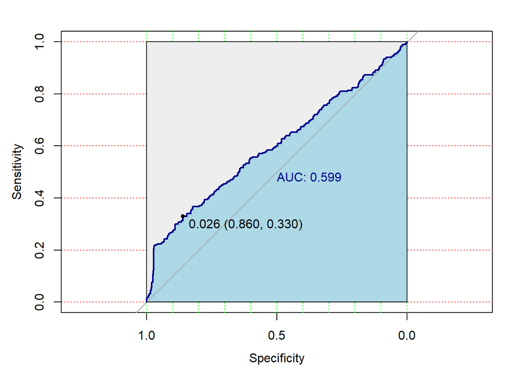

```r
plot.roc(dataTest_aux$Rent, probability[,2],col="darkblue", print.auc = TRUE,  auc.polygon=TRUE, grid=c(0.1, 0.2),
         grid.col=c("green", "red"), max.auc.polygon=TRUE,
         auc.polygon.col="lightblue", print.thres=TRUE)
```

# Decision tree

Now, let’s make a Machine learning algorithm: a decision tree.

The first step is to choose the values of our hyper-parameters:

- minsplit: minimum number of observations in a node before before a split
- maxdepth: maximum depth of any node of the final tree
- cp: degree of complexity, the smaller the more branches

The choice is made with some typical values. The cp is is set to 0.01 because if a higher value is chosen, the future graph created won’t provide us as many information.

```r
# Hyper-parameters choice
control = rpart.control(minsplit = 30, maxdepth = 10, cp=0.01)
```

A model is created using Rent as our study variable and then, together with the train set, a plot can be formed explaining how our data is divided in order to classify the Rent category.

[figure not shown]

```r
dtFit = rpart(Rent ~., data=dataTrain, method = "class", control = control)

# library rattle provide us fancyRpartPlot which shows better plots.
fancyRpartPlot(dtFit)
```

Notice that the plot always divides in two branches: moving to the right means a no for the previous condition and to the left a yes.

Also, it is notice that some important variables are Bathroom, city and BHK in order to study our data set.

Variable importance can be check:

```r
df <- data.frame(imp = dtFit$variable.importance)
df
```

```
##                         imp
## Bathroom         306.287105
## BHK              256.884372
## City             224.510062
## Point.of.Contact 212.868203
## Size             167.171143
## Area.Type         37.783106
## Tenant.Preferred   3.689533
```

So, Bathroom, BHK and City are confirmed to be the most important variables in our study. Others, such as Tenant.preferred, does not provide us useful information for predicting Rent.

Now, let’s start with the training of our model.

```r
caret.fit <- train(Rent ~.,
                   data = dataTrain,
                   method = "rpart",
                   control=rpart.control(minsplit = 30, maxdepth = 10),
                   trControl = trainControl(method = "cv", number = 5),
                   tuneLength=10)
caret.fit
```

```
## CART
##
## 3382 samples
##    9 predictor
##    4 classes: 'Cheap', 'Expensive', 'Very_cheap', 'Very_expensive'
##
## No pre-processing
## Resampling: Cross-Validated (5 fold)
## Summary of sample sizes: 2705, 2705, 2706, 2706, 2706
## Resampling results across tuning parameters:
##
##   cp           Accuracy   Kappa
##   0.001376778  0.6614471  0.51064412
##   0.001835704  0.6626341  0.51216871
##   0.002065168  0.6638166  0.51388085
##   0.002294631  0.6635208  0.51334006
##   0.004130335  0.6576080  0.50483342
##   0.007189842  0.6531714  0.49905169
##   0.020192749  0.6348317  0.47384955
##   0.041762276  0.6218297  0.45655257
##   0.079394218  0.5842632  0.40074408
##   0.230839835  0.3822944  0.04978228
##
## Accuracy was used to select the optimal model using the largest value.
## The final value used for the model was cp = 0.002065168.
```

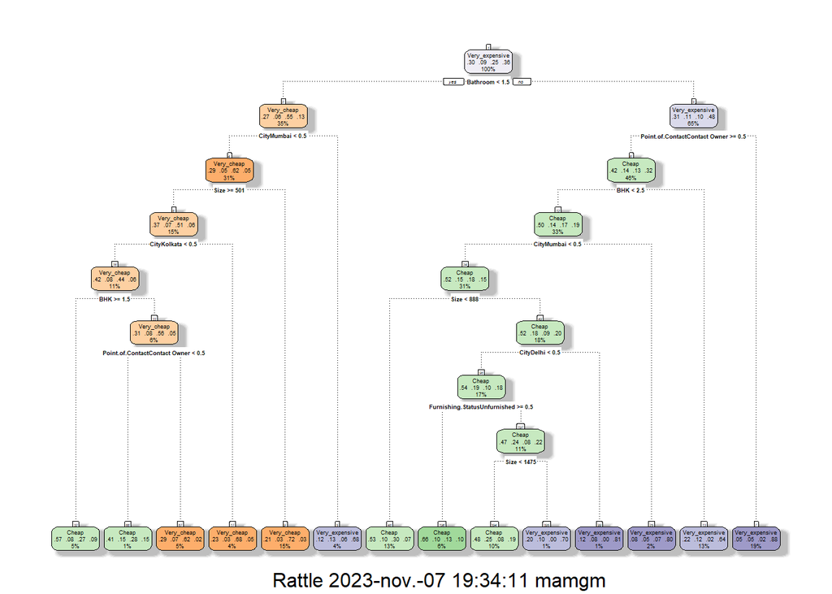

```r
fancyRpartPlot(caret.fit$finalModel)
```

As it may be difficult to read it, the same information can be displayed by written.

```r
rpart.rules(dtFit, style = "tallw")
```

```
##                         Che Exp Ver Ver
## Rent is Cheap          [.54 .15 .19 .13] when
##                                          Bathroom >= 2
##                                          Point.of.Contact is Contact Owner
##                                          City is Bangalore or Chennai or Hyderabad or Kolkata
##                                          BHK < 3
##
## Rent is Very_cheap     [.29 .05 .62 .05] when
##                                          Bathroom < 2
##                                          City is Bangalore or Chennai or Delhi or Hyderabad or Kolkata
##
## Rent is Very_expensive [.24 .11 .08 .57] when
##                                          Bathroom >= 2
##                                          Point.of.Contact is Contact Owner
##                                          City is Delhi or Mumbai
##                                          BHK < 3
##
## Rent is Very_expensive [.22 .12 .02 .64] when
##                                          Bathroom >= 2
##                                          Point.of.Contact is Contact Owner
##                                          BHK >= 3
##
## Rent is Very_expensive [.12 .13 .06 .68] when
##                                          Bathroom < 2
##                                          City is Mumbai
##
## Rent is Very_expensive [.05 .05 .02 .88] when
##                                          Bathroom >= 2
##                                          Point.of.Contact is Contact Agent
```

With this model, the predictions can be done to our test set, saving them in dtPred.

```r
dtProb <- predict(caret.fit, dataTest, type = "prob")
threshold = 0.2
# all will be cheap and then they will be changed.
dtPred = rep("Cheap", nrow(dataTest))
dtPred[which(dtProb[,2] > threshold)] = "Expensive"
dtPred[which(dtProb[,3] > threshold)] = "Very_cheap"
dtPred[which(dtProb[,4] > threshold)] = "Very_expensive"
```

A confusion matrix is computed comparing our predicion with the actual value of Rent.

```r
CM = confusionMatrix(factor(dtPred), dataTest$Rent)$table
CM
```

```
##                 Reference
## Prediction       Cheap Expensive Very_cheap Very_expensive
##   Cheap             35         9         13              7
##   Expensive         48        14          4             22
##   Very_cheap       121        22        188             19
##   Very_expensive    46        34         10            252
```

```r
confusionMatrix(factor(dtPred), dataTest$Rent)$overall[1]
```

```
##  Accuracy
## 0.5793839
```

Another way of measuring the success of our model is by the cost it has to the company. Let’s assume the following one:

- Cost of true negatives is 0
- Cost of false negatives is 500
- Cost of false positives is 100
- Cost of true positives is 140

```r
cost.unit <- c(0, 100, 500, 140)
```

The lower the cost obtained, the better our model will be.

```r
# doing the mean
cost = sum(as.vector(CM)*cost.unit)/sum(CM)
cost
```

```
## [1] 274.5024
```

# Random forest

Let’s make the random forest technique. The function randomForest will be used and the standard hyper parameters will be chosen.

```r
rf.train <- randomForest(Rent ~., data=dataTrain,                      ntree=200,mtry=10,importance=TRUE, do.trace=T)
```

[output not shown]

[output cut: 186 more lines]

With our random tree created, a prediction can be done on our dataTest.

```r
rf.pred <- predict(rf.train, newdata=dataTest)
#CM done on comparing the predicted value and the real value
confusionMatrix(rf.pred, dataTest$Rent)
```

```
## Confusion Matrix and Statistics
##
##                 Reference
## Prediction       Cheap Expensive Very_cheap Very_expensive
##   Cheap             69        10         44             11
##   Expensive         46        15         15             15
##   Very_cheap        30         4        128              5
##   Very_expensive   105        50         28            269
##
## Overall Statistics
##
##                Accuracy : 0.5699
##                  95% CI : (0.5357, 0.6036)
##     No Information Rate : 0.3555
##     P-Value [Acc > NIR] : < 2.2e-16
##
##                   Kappa : 0.3874
##
##  Mcnemar's Test P-Value : < 2.2e-16
##
## Statistics by Class:
##
##                      Class: Cheap Class: Expensive Class: Very_cheap
## Sensitivity               0.27600          0.18987            0.5953
## Specificity               0.89057          0.90065            0.9380
## Pos Pred Value            0.51493          0.16484            0.7665
## Neg Pred Value            0.74507          0.91501            0.8715
## Prevalence                0.29621          0.09360            0.2547
## Detection Rate            0.08175          0.01777            0.1517
## Detection Prevalence      0.15877          0.10782            0.1979
## Balanced Accuracy         0.58329          0.54526            0.7667
##                      Class: Very_expensive
## Sensitivity                         0.8967
## Specificity                         0.6636
## Pos Pred Value                      0.5951
## Neg Pred Value                      0.9209
## Prevalence                          0.3555
## Detection Rate                      0.3187
## Detection Prevalence                0.5355
## Balanced Accuracy                   0.7801
```

Now, we can optimize the value of the hyper parameters with the following function. It will be based on a cost.

```r
EconomicCost <- function(data, lev = NULL, model = NULL)
{
  y.pred = data$pred
  y.true = data$obs
  CM = confusionMatrix(y.pred, y.true)$table
  out = sum(as.vector(CM)*cost.unit)/sum(CM)
  names(out) <- c("EconomicCost")
  out
}


ctrl <- trainControl(method = "cv", number = 5,
                     classProbs = TRUE,
                     summaryFunction = EconomicCost,
                     verboseIter=T)

EconomicCost(data = data.frame(pred  = rf.pred, obs = dataTest$Rent))
```

```
## EconomicCost
##     184.6919
```

It will be controlled with the function of control. The function EconomicCost will be now used.

Our cost will be the following one:

```r
EconomicCost(data = data.frame(pred  = rf.pred, obs = dataTest$Rent))
```

```
## EconomicCost
##     184.6919
```

Now, let’s make a RF with the previous results.

```r
rf.train <- train(Rent ~.,
                  method = "rf",
                  data = dataTrain,
                  preProcess = c("center", "scale"),
                  ntree = 200,
                  tuneGrid = expand.grid(mtry=c(6,8,10)),
                  metric = "EconomicCost",
                  maximize = F,
                  trControl = ctrl)
```

With this RF the variable importance can be shown:

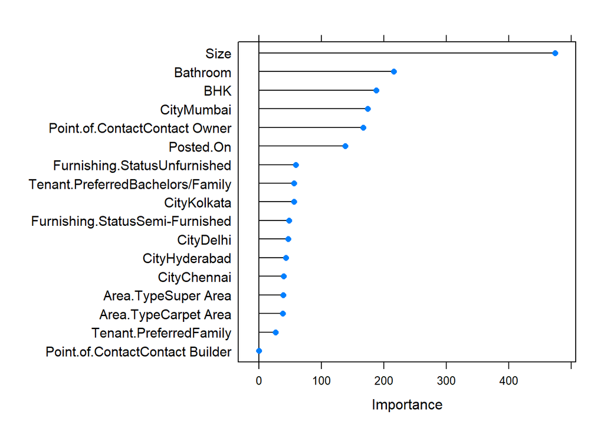

```r
rf_imp <- varImp(rf.train, scale = F)
plot(rf_imp, scales = list(y = list(cex = .95)))
```

Now the prediction can be done with the tree we have created. Comparing the real result with the predicted one.

```r
rfPred = predict(rf.train, newdata=dataTest)
CM = confusionMatrix(factor(rfPred), dataTest$Rent)$table
cost = sum(as.vector(CM)*cost.unit)/sum(CM)
cost
```

```
## [1] 172.4408
```

The threshold in the Bayes Rules may be also interesting.

```r
threshold = 0.2
rfProb = predict(rf.train, newdata=dataTest, type="prob")
threshold = 0.2
dtPred = rep("Cheap", nrow(dataTest))
# 4 levels!
dtPred[which(rfProb[,2] > threshold)] = "Expensive"
dtPred[which(rfProb[,3] > threshold)] = "Very cheap"
dtPred[which(rfProb[,4] > threshold)] = "Very expensive"
CM = confusionMatrix(factor(rfPred), dataTest$Rent)$table
cost = sum(as.vector(CM)*cost.unit)/sum(CM)
cost
```

```
## [1] 172.4408
```

# Multinomial Naive-Bayes classification

Another method is going to be done. Multinomial Naive Bayes model is going to be performed: all class conditional distributions are assumed to be multinomial and independent.

Only numeric variables will be used, and the study variable will be separated from the other ones.

```r
NB.fit <- multinomial_naive_bayes(as.matrix(dataTrain[,c(2,3,4,9)]),
                                  dataTrain$Rent,
                                  laplace=.6)
```

Now, let’s make a prediction from our fit and compare it to the real values of the data test.

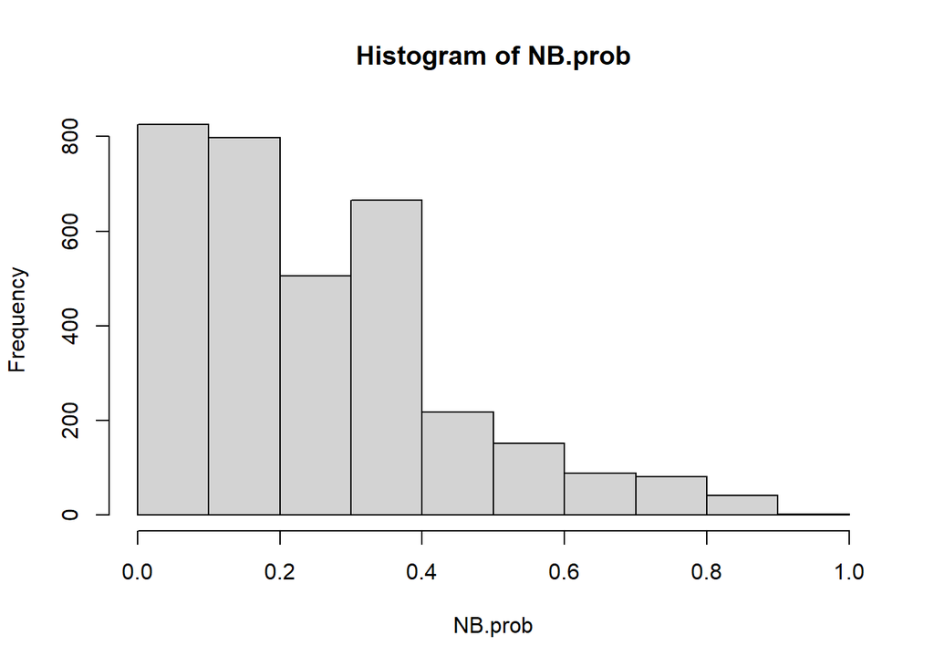

```r
NB.pred <- predict(NB.fit, as.matrix(dataTest[,c(2,3,4,9)]))

NB.prob <- predict(NB.fit, as.matrix(dataTest[,c(2,3,4,9)]),type="prob")
hist(NB.prob)
```

```r
# CM to test perfomance of the fit
confusionMatrix(NB.pred,dataTest$Rent)
```

```
## Confusion Matrix and Statistics
##
##                 Reference
## Prediction       Cheap Expensive Very_cheap Very_expensive
##   Cheap             48        14         33             49
##   Expensive          0         0          0              0
##   Very_cheap        78        15        137             77
##   Very_expensive   124        50         45            174
##
## Overall Statistics
##
##                Accuracy : 0.4254
##                  95% CI : (0.3917, 0.4595)
##     No Information Rate : 0.3555
##     P-Value [Acc > NIR] : 1.608e-05
##
##                   Kappa : 0.1687
##
##  Mcnemar's Test P-Value : < 2.2e-16
##
## Statistics by Class:
##
##                      Class: Cheap Class: Expensive Class: Very_cheap
## Sensitivity               0.19200           0.0000            0.6372
## Specificity               0.83838           1.0000            0.7297
## Pos Pred Value            0.33333              NaN            0.4463
## Neg Pred Value            0.71143           0.9064            0.8547
## Prevalence                0.29621           0.0936            0.2547
## Detection Rate            0.05687           0.0000            0.1623
## Detection Prevalence      0.17062           0.0000            0.3637
## Balanced Accuracy         0.51519           0.5000            0.6835
##                      Class: Very_expensive
## Sensitivity                         0.5800
## Specificity                         0.5974
## Pos Pred Value                      0.4427
## Neg Pred Value                      0.7206
## Prevalence                          0.3555
## Detection Rate                      0.2062
## Detection Prevalence                0.4656
## Balanced Accuracy                   0.5887
```

# Tuning

Let’s make a tuning model. Then compare the obtained predicted values with the real ones.

```r
ctrl <- trainControl(method = "repeatedcv",
                     repeats = 1,
                     number = 10,
                     verboseIter = T)

nb_grid <-   expand.grid(usekernel = c(TRUE, FALSE),
                         laplace = c(0, 0.5, 1),
                         adjust = c(0.5, 1, 1.5))

nb_mod <- train(x = dataTrain[,c(-1)],
                y = dataTrain$Rent,
                method = "naive_bayes",
                trControl = ctrl,
                tuneGrid = nb_grid)
```

[output not shown]

[output cut: 17 more lines]

[output not shown]

```r
nb_pred <- predict(nb_mod,
                   newdata = dataTest[,c(-1)])

confusionMatrix(nb_pred, dataTest$Rent)
```

```
## Confusion Matrix and Statistics
##
##                 Reference
## Prediction       Cheap Expensive Very_cheap Very_expensive
##   Cheap            151        49         50             58
##   Expensive          1         0          0              0
##   Very_cheap        61         6        156             12
##   Very_expensive    37        24          9            230
##
## Overall Statistics
##
##                Accuracy : 0.6363
##                  95% CI : (0.6028, 0.6688)
##     No Information Rate : 0.3555
##     P-Value [Acc > NIR] : < 2.2e-16
##
##                   Kappa : 0.4763
##
##  Mcnemar's Test P-Value : 1.23e-15
##
## Statistics by Class:
##
##                      Class: Cheap Class: Expensive Class: Very_cheap
## Sensitivity                0.6040         0.000000            0.7256
## Specificity                0.7357         0.998693            0.8744
## Pos Pred Value             0.4903         0.000000            0.6638
## Neg Pred Value             0.8153         0.906287            0.9031
## Prevalence                 0.2962         0.093602            0.2547
## Detection Rate             0.1789         0.000000            0.1848
## Detection Prevalence       0.3649         0.001185            0.2784
## Balanced Accuracy          0.6698         0.499346            0.8000
##                      Class: Very_expensive
## Sensitivity                         0.7667
## Specificity                         0.8713
## Pos Pred Value                      0.7667
## Neg Pred Value                      0.8713
## Prevalence                          0.3555
## Detection Rate                      0.2725
## Detection Prevalence                0.3555
## Balanced Accuracy                   0.8190
```

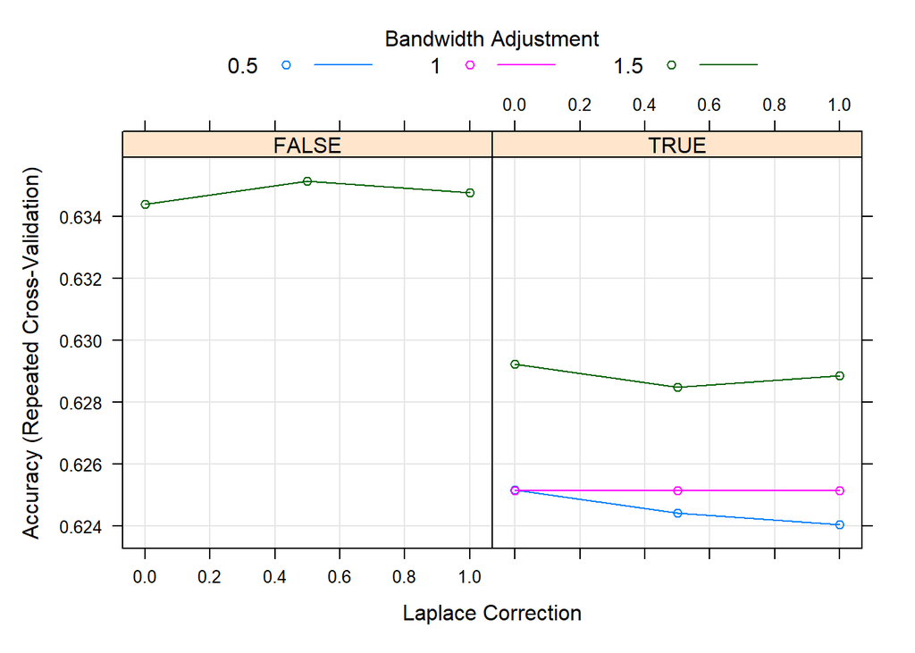

```r
plot(nb_mod)
```

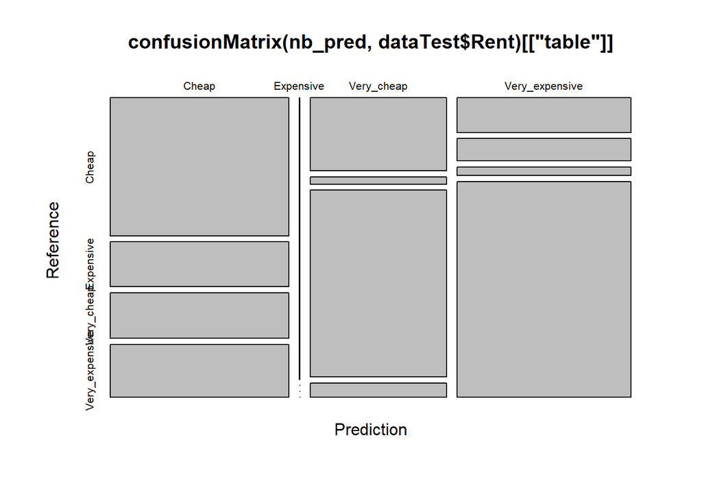

```r
plot(confusionMatrix(nb_pred,dataTest$Rent)[["table"]])
```

# Conclusions on CLASSIFICATION

Recalling two of the most important graphs obtained: * The decision tree has provided us an useful divison when deciding the levels of Rent: Bathroom, City and BHK are some of the most important variables taken into account.

- The Var.Imp.Plot of the Random Forest also reaffirms one of our initial assumptions: size is highly correlated with rent. Others such as the Area Type and Furniture does not aport much to our model.

# Advanced regression

In regression, our study variable must be numeric, so data.num is going to eb used. We must create again a train and a test set. Before that, all our str must be converted into numbers.

First we convert it to factors in order to know the levels of the variable. Then, we use the function varaible to redenominate each level with a number.

```r
# Area.Type
data.num$Area.Type = as.factor(data.num$Area.Type)
levels(data.num$Area.Type)
```

```
## [1] "Built Area"  "Carpet Area" "Super Area"
```

```r
data.num$Area.Type = factor(data.num$Area.Type ,levels = c("Built Area","Carpet Area", "Super Area"),labels=c(1,2,3))

#City
data.num$City = as.factor(data.num$City)
levels(data.num$City)
```

```
## [1] "Bangalore" "Chennai"   "Delhi"     "Hyderabad" "Kolkata"   "Mumbai"
```

```r
data.num$City = factor(data.num$City, levels = c("Bangalore","Chennai", "Delhi", "Hyderabad", "Kolkata", "Mumbai"),labels=c(1,2,3,4,5,6))

# Furnishing.Status
data.num$Furnishing.Status = as.factor(data.num$Furnishing.Status)
levels(data.num$Furnishing.Status)
```

```
## [1] "Furnished"      "Semi-Furnished" "Unfurnished"
```

```r
data.num$Furnishing.Status = factor(data.num$Furnishing.Status, levels = c("Furnished", "Semi-Furnished", "Unfurnished"),labels=c(1,2,3))

# Tenant.Preferred
data.num$Tenant.Preferred = as.factor(data.num$Tenant.Preferred)
levels(data.num$Tenant.Preferred)
```

```
## [1] "Bachelors"        "Bachelors/Family" "Family"
```

```r
data.num$Tenant.Preferred = factor(data.num$Tenant.Preferred, levels = c("Bachelors", "Bachelors/Family", "Family"),labels=c(1,2,3))


# Point.of.Contact
data.num$Point.of.Contact = as.factor(data.num$Point.of.Contact)
data.num$Point.of.Contact = factor(data.num$Point.of.Contact, levels = c("Contact Agent", "Contact Builder", "Contact Owner"),labels=c(1,2,3))


# Creating of training and test set with the initial split.
dataTrain.num = data.num[spl,]
dataTest.num = data.num[-spl,]
```

# A benchmark

```r
benchFit <- lm(Rent ~ 1, data=data.num)
benchFit$coefficients
```

```
## (Intercept)
##    19286.16
```

```r
predictions <- predict(benchFit, newdata=dataTest.num)
RMSE <- sqrt(mean((predictions - dataTest.num$Rent)^2))
RMSE
```

```
## [1] 13243.02
```

# Statistical learning

After using caret package to create a ctrl, we wil have to create a model in which variables can interact with each other: * The syntax x1:x2 tells R to include an interaction term between x1 and x2. * The syntax x1*x2 simultaneously includes x1, x2, and the interaction term x1:x2 as predictors; it is a shorthand for # x1+x2+x1:x2

```r
ctrl <- trainControl(method = "repeatedcv",
                     number = 5, repeats = 1)

linFit <- lm(Rent ~ log(Size) + Bathroom*BHK + Posted.On + City + Area.Type + Point.of.Contact + Tenant.Preferred + Furnishing.Status, data=dataTrain.num)

summary(linFit)
```

```
##
## Call:
## lm(formula = Rent ~ log(Size) + Bathroom * BHK + Posted.On +
##     City + Area.Type + Point.of.Contact + Tenant.Preferred +
##     Furnishing.Status, data = dataTrain.num)
##
## Residuals:
##    Min     1Q Median     3Q    Max
## -36236  -4567   -549   3529  41655
##
## Coefficients:
##                    Estimate Std. Error t value Pr(>|t|)
## (Intercept)         -3456.7     8218.9  -0.421 0.674086
## log(Size)            2892.9      274.4  10.542  < 2e-16 ***
## Bathroom             1423.9      531.9   2.677 0.007463 **
## BHK                  3324.0      428.3   7.762 1.10e-14 ***
## Posted.On             409.3      173.8   2.355 0.018579 *
## City2               -1348.9      440.4  -3.063 0.002211 **
## City3                1745.7      526.6   3.315 0.000926 ***
## City4               -1773.7      446.3  -3.974 7.22e-05 ***
## City5               -3857.3      520.8  -7.407 1.63e-13 ***
## City6               17121.4      537.0  31.884  < 2e-16 ***
## Area.Type2          -1465.7     7949.0  -0.184 0.853721
## Area.Type3          -1446.7     7943.7  -0.182 0.855497
## Point.of.Contact2   -7539.9     7956.0  -0.948 0.343350
## Point.of.Contact3   -9132.1      415.0 -22.006  < 2e-16 ***
## Tenant.Preferred2   -1198.9      397.1  -3.019 0.002557 **
## Tenant.Preferred3   -2779.8      584.6  -4.755 2.07e-06 ***
## Furnishing.Status2  -3119.6      439.6  -7.097 1.55e-12 ***
## Furnishing.Status3  -4508.1      447.7 -10.069  < 2e-16 ***
## Bathroom:BHK          887.4      166.2   5.340 9.93e-08 ***
## ---
## Signif. codes:  0 '***' 0.001 '**' 0.01 '*' 0.05 '.' 0.1 ' ' 1
##
## Residual standard error: 7932 on 3363 degrees of freedom
## Multiple R-squared:  0.6792, Adjusted R-squared:  0.6775
## F-statistic: 395.5 on 18 and 3363 DF,  p-value: < 2.2e-16
```

Our model has a r squared of 67%! It is a good model.

```r
Model = Rent ~ log(Size) + Bathroom:BHK + Posted.On + City + Area.Type + Furnishing.Status + Tenant.Preferred
```

# Linear Regression

We will use the previous model and will train it.

```r
lm_tune <- train(Model, data = dataTrain.num,
                 method = "lm",
                 preProc=c('scale', 'center'),
                 trControl = ctrl)
lm_tune
```

```
## Linear Regression
##
## 3382 samples
##    8 predictor
##
## Pre-processing: scaled (14), centered (14)
## Resampling: Cross-Validated (5 fold, repeated 1 times)
## Summary of sample sizes: 2706, 2704, 2706, 2706, 2706
## Resampling results:
##
##   RMSE      Rsquared   MAE
##   8553.865  0.6256934  6084.321
##
## Tuning parameter 'intercept' was held constant at a value of TRUE
```

Now, we predict with the lr model.

```r
# creating a matrix where all predictions will be saved so alter comparisons can be done.
test_results <- data.frame(Rent = dataTest.num$Rent)
test_results$lm <- predict(lm_tune, dataTest.num)
postResample(pred = test_results$lm,  obs = dataTest.num$Rent)
```

```
##         RMSE     Rsquared          MAE
## 8230.9477494    0.6140855 5831.5433417
```

Plotting the real values vs the model predictions!

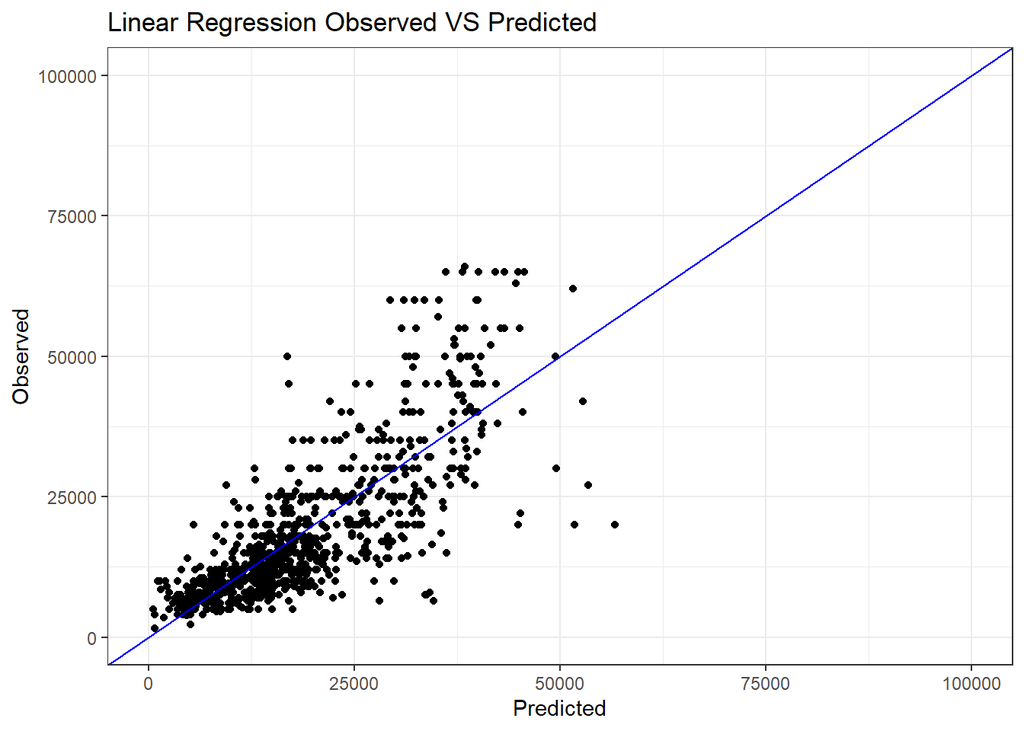

```r
qplot(test_results$lm, test_results$Rent) +
  labs(title="Linear Regression Observed VS Predicted", x="Predicted", y="Observed") +
  lims(x = c(0, 100000), y = c(0, 100000)) +
  geom_abline(intercept = 0, slope = 1, colour = "blue") +
  theme_bw()
```

# The Lasso

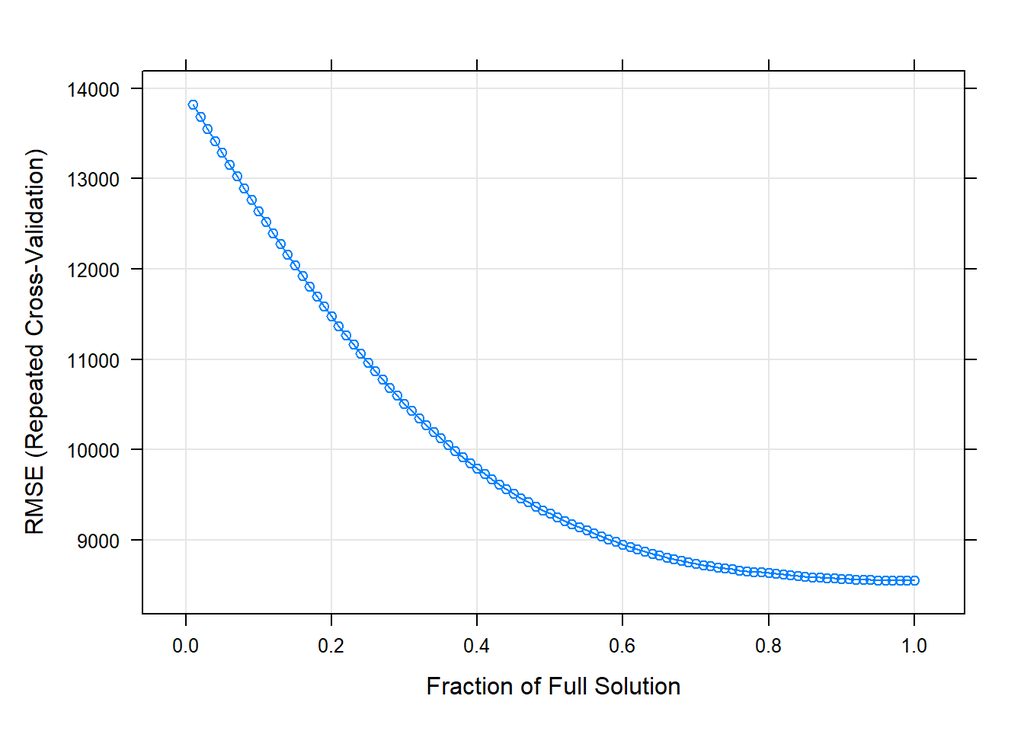

```r
lasso_grid <- expand.grid(fraction = seq(.01, 1, length = 100))

lasso_tune <- train(Model, data = dataTrain.num,
                    method='lasso',
                    preProc=c('scale','center'),
                    tuneGrid = lasso_grid,
                    trControl=ctrl)
plot(lasso_tune)
```

```r
lasso_tune$bestTune
```

```
##     fraction
## 100        1
```

```r
test_results$lasso <- predict(lasso_tune, dataTest.num)
postResample(pred = test_results$lasso,  obs = test_results$Rent)
```

```
##         RMSE     Rsquared          MAE
## 8230.9477494    0.6140855 5831.5433417
```

# kNN

Let’s check the names for hyper-parameters

```r
modelLookup('kknn')
```

```
##   model parameter           label forReg forClass probModel
## 1  kknn      kmax Max. #Neighbors   TRUE     TRUE      TRUE
## 2  kknn  distance        Distance   TRUE     TRUE      TRUE
## 3  kknn    kernel          Kernel   TRUE     TRUE      TRUE
```

Training a model for later testing.

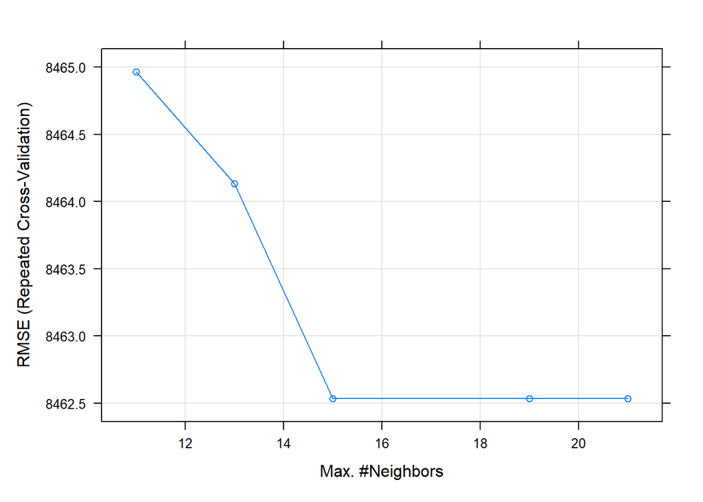

```r
knn_tune <- train(Model,
                  data = dataTrain.num,
                  method = "kknn",
                  preProc=c('scale','center'),
                  tuneGrid = data.frame(kmax=c(11,13,15,19,21),distance=2,kernel='optimal'),
                  trControl = ctrl)
# our model param.
plot(knn_tune)
```

```r
test_results$knn <- predict(knn_tune, dataTest.num)

# saving in the matrix results.
postResample(pred = test_results$knn,  obs = test_results$Rent)
```

```
##         RMSE     Rsquared          MAE
## 7867.6982204    0.6472163 5375.6279016
```

# Ensemble

Let’s summarize the MAE for all the tools from the matrix test_results.

```r
apply(test_results[-1], 2, function(x) mean(abs(x - test_results$Rent)))
```

```
##       lm    lasso      knn
## 5831.543 5831.543 5375.628
```

```r
# Combination of them, Normal mean: (n1 + n2 + n3) / 3
test_results$comb = (test_results$lm + test_results$lasso + test_results$knn)/3

postResample(pred = test_results$comb,  obs = test_results$Rent)
```

```
##         RMSE     Rsquared          MAE
## 7795.4980386    0.6535749 5412.0074631
```

A high R squared has been obtained, which means that our model is valid throught out all methods.

# Final predictions

```r
yhat = test_results$comb

head(yhat) # show the prediction for 6 home prices
```

```
## [1] 12190.770  9721.531 14916.916 21802.003 13967.741  7050.690
```

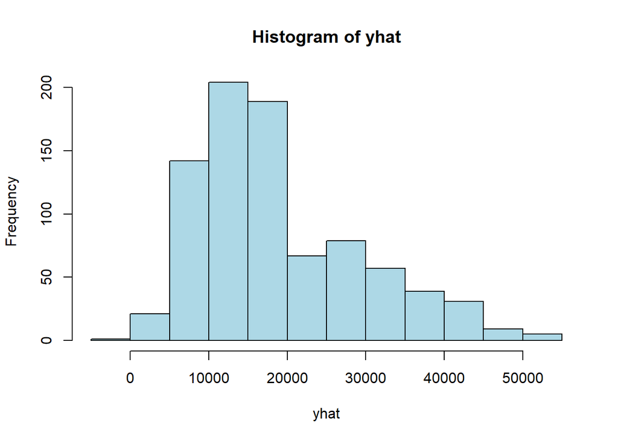

```r
hist(yhat, col="lightblue")
```

# Prediction intervals

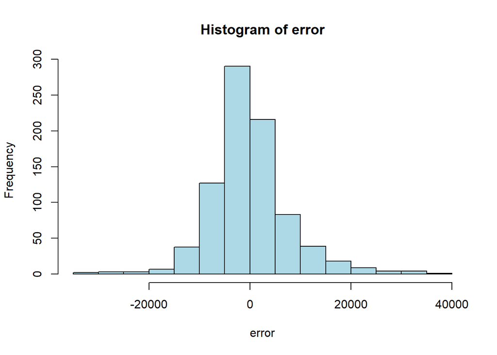

```r
y = test_results$Rent
error = y-yhat
hist(error, col="lightblue")
```

We can split the testing set in two parts: one to measure the size of the noise, and the other one to compute the intervals from that size

```r
noise = error[1:100]

lwr = yhat[101:length(yhat)] + quantile(noise,0.05, na.rm=T)
upr = yhat[101:length(yhat)] + quantile(noise,0.95, na.rm=T)

predictions = data.frame(real=y[101:length(y)], fit=yhat[101:length(yhat)], lwr=lwr, upr=upr)

predictions = predictions %>% mutate(out=factor(if_else(real<lwr | real>upr,1,0)))

# how many real observations are out of the intervals?
mean(predictions$out==1)
```

```
## [1] 0.25
```

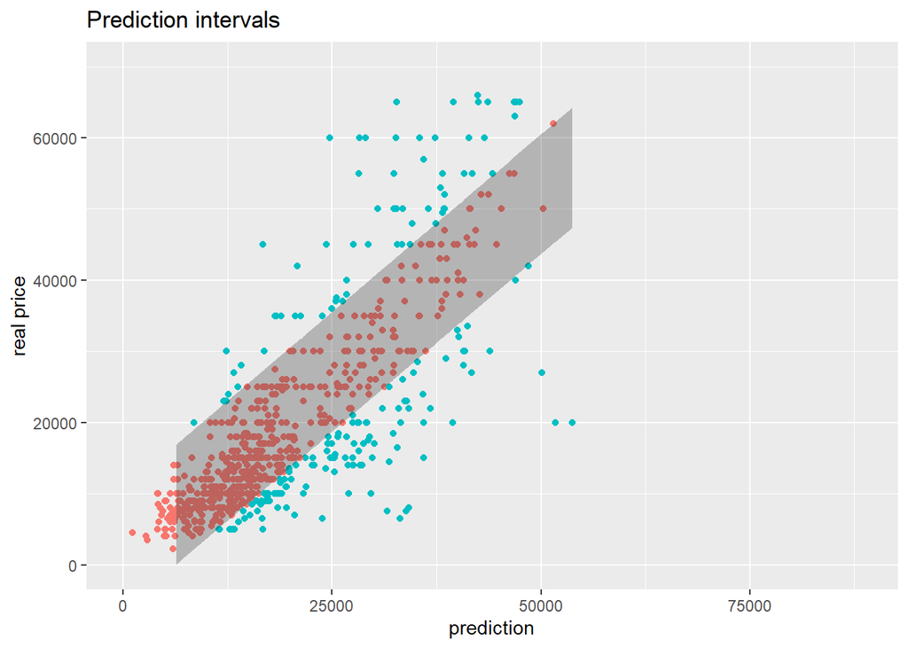

```r
ggplot(predictions, aes(x=fit, y=real))+
  geom_point(aes(color=out)) + theme(legend.position="none") +
  xlim(0, 88300) + ylim(0,  70000)+
  geom_ribbon(data=predictions,aes(ymin=lwr,ymax=upr),alpha=0.3) +
  labs(title = "Prediction intervals", x = "prediction",y="real price")
```

# Conclusions

Through out all this project several methods have been done (classification and regression) in order to try to predict an outcome on Rent depending on the predictors.

Also, using advanced regression important models have been created with a high R squared.

What are the final insights?

Rent is not perfectly predicteable and that’s why accuracies never give 100%! Despite this, accuracies tell us that the models would work quite well.